# Trabalho 03

.

# Séries Temporais

#### Igor Kuivjogi / Kaíque Ferreira / Nilo Célio

#### **3° Trabalho de Séries Temporais**

##### 18 de Agosto de 2020

.

# Análise Descritiva

## Gráfico da Série

Nesse gráfico abaixo conseguimos ver de forma gráfica o conjunto de dados referente a produção física industrial nas seguintes variáveis:

- Produtos Alimentares total mensal
- Data: Mês de janeiro de 1985 a dezembro de 1999
- Foi desconsiderado os valores de janeiro de 2000 a julho de 2000

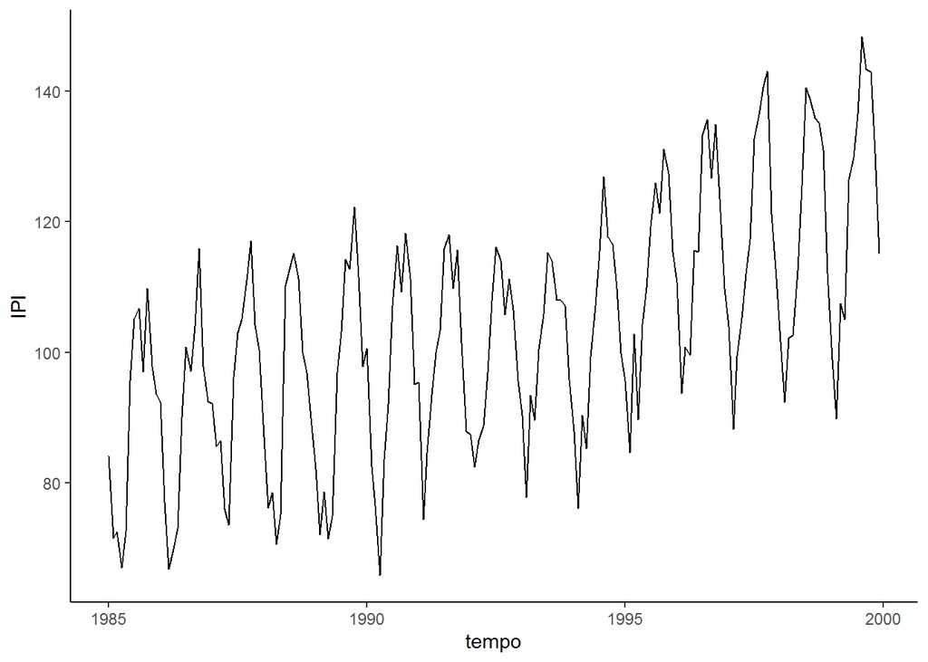

## Subsérie IPI

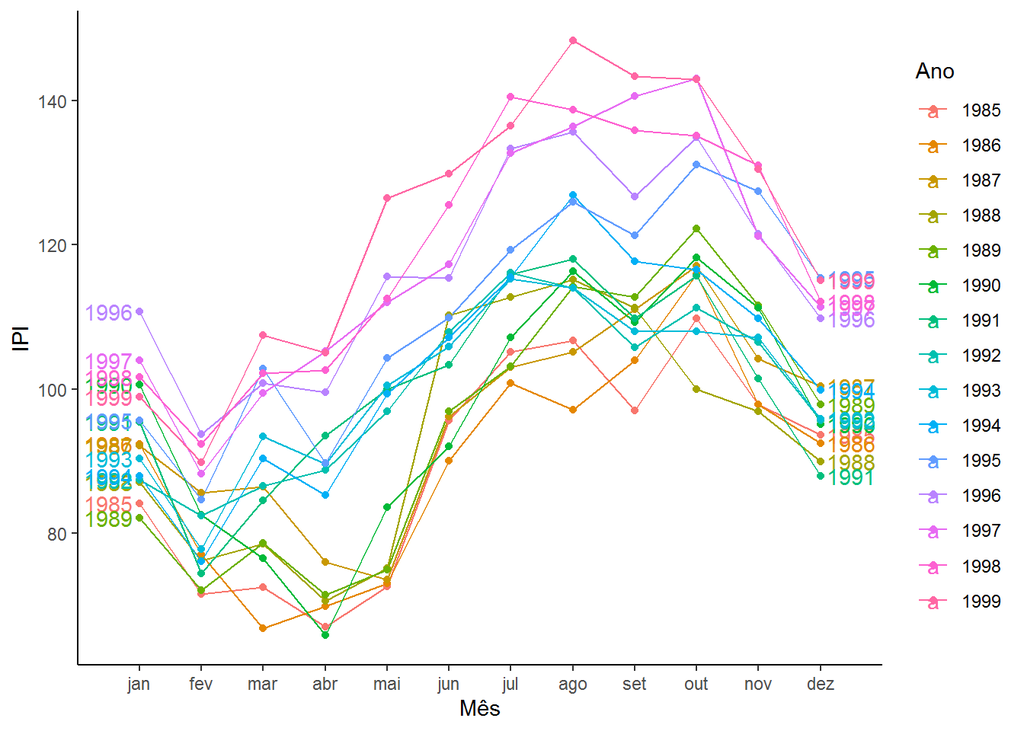

## Autocorrelação

Abaixo podemos avaliar o gráfico de autocorrelação da série original

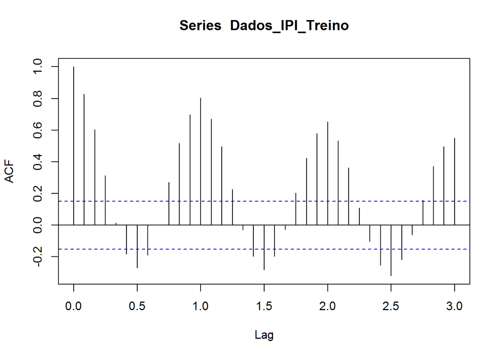

## Autocorrelação Parcial

Abaixo podemos avaliar o gráfico de autocorrelação parcial da série original

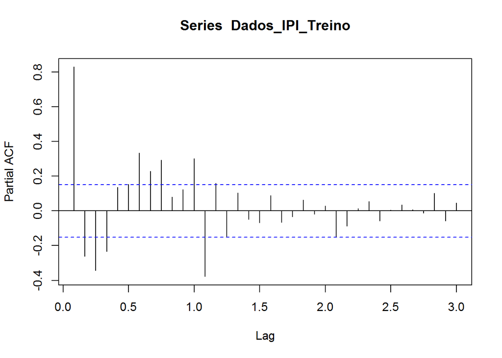

## Diferenciação

Para tentar melhorar os resultados ao aplicar um modelo de séries temporais vamos diferenciar a série IPI e avaliar novamente as autocorrelações

### Autocorrelação

Podemos análisar a autocorrelação da série após uma diferenciação $(1 - B^{12})Z_t$

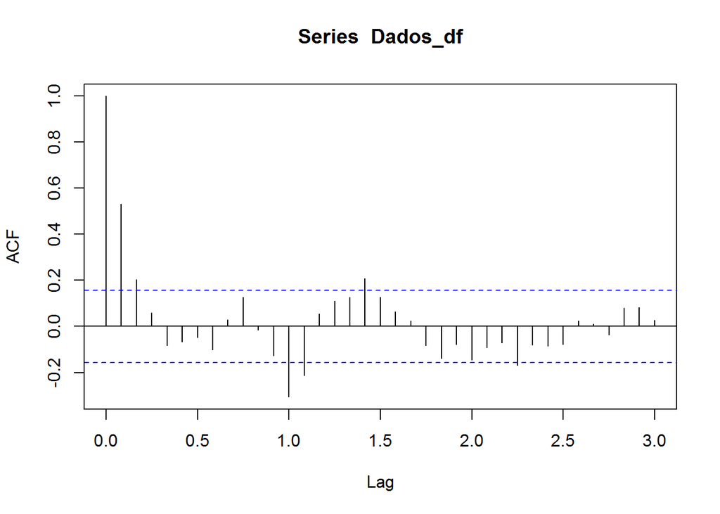

### Autocorrelação Parcial

Podemos analisar a autocorrelação parcial da série após uma diferenciação $(1 - B^{12})Z_t$

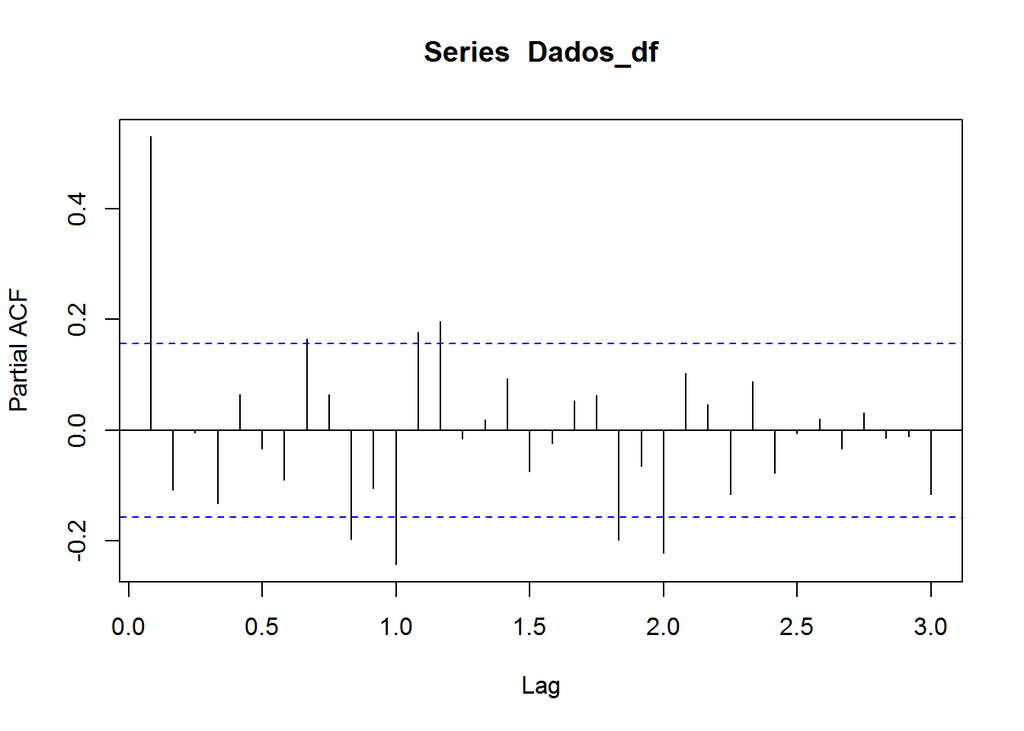

# Modelo Previsão

## Auto-arima

Vamos utilizar a função *auto.arima* para encontrar um primeiro modelo sugerido e assim fazer o testes de diagnósticos para avaliar seus ajuste em relação à série dos dados

```
## Series: Dados_IPI_Treino
## ARIMA(1,1,5)(0,1,2)[12]
##
## Coefficients:
##          ar1      ma1     ma2     ma3      ma4     ma5     sma1     sma2
##       0.6901  -1.1195  0.0513  0.0519  -0.1243  0.1702  -0.5236  -0.1668
## s.e.  0.3463   0.3488  0.1882  0.1633   0.1187  0.0801   0.0887   0.0911
##
## sigma^2 estimated as 30.59:  log likelihood=-485.43
## AIC=988.87   AICc=990.11   BIC=1016.26
##
## Training set error measures:
##                     ME     RMSE      MAE         MPE    MAPE     MASE
## Training set 0.1504246 5.173629 3.919147 -0.06518435 3.95951 0.666202
##                     ACF1
## Training set -6.5006e-05
```

Percebemos que esse é o modelo indicado pelo *auto.arima*

$$(1-\phi_1B)(\psi_1B-\psi_2B^2-\psi_3B^3-\psi_4B^4-\psi_5B^5)(1-B^{12})z_t=(1-\Theta_1B-\Theta_2B^2)a_t$$

### Diagnostico

Vamos realizar testes de diagnósticos para avaliar o modelo sugerido pelo *auto.arima* atravéz dos gráficos de autocorrelação e de autocorrelação parcial e também com o teste Ljung-Box

#### Autocorrelação

Podemos analisar a autocorrelação da série para o modelo sugerido pelo *auto.arima*

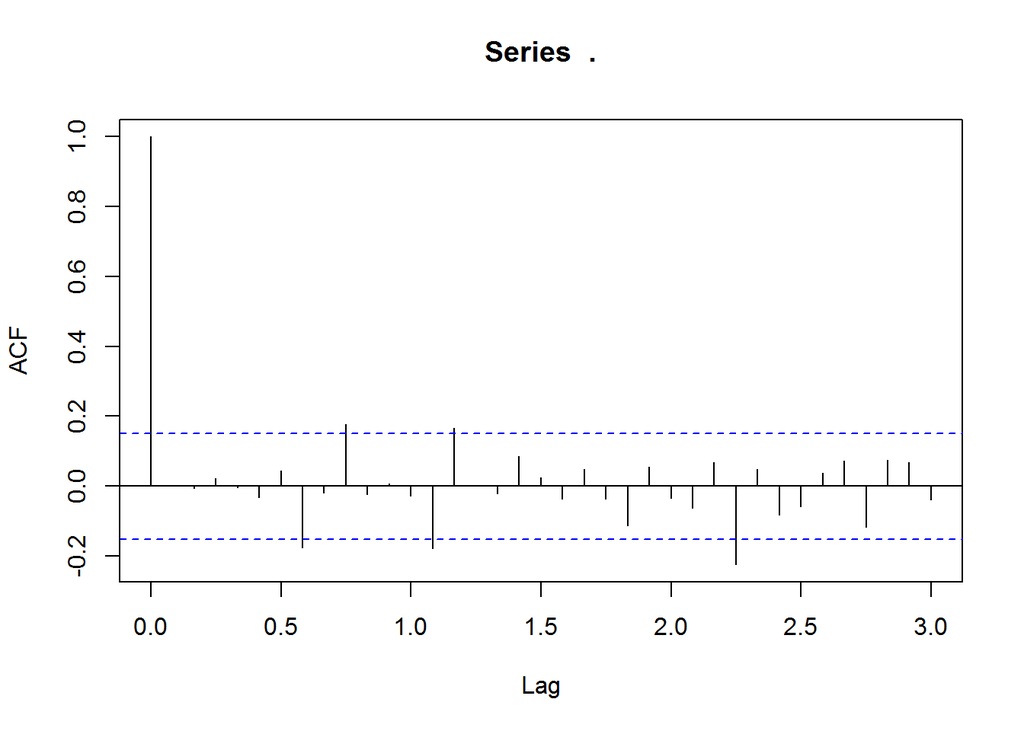

#### Autocorrelação Parcial

Podemos analisar a autocorrelação parcial da série para o modelo sugerido pelo *auto.arima*

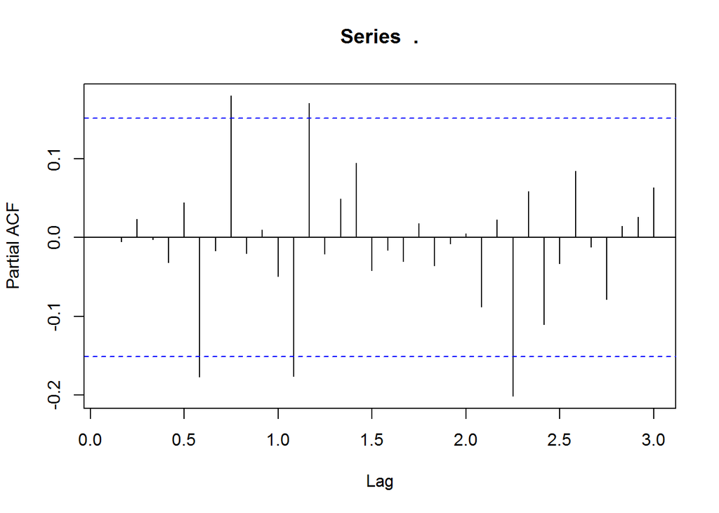

#### Teste Ljung-Box

```
##
##  Ljung-Box test
##
## data:  Residuals from ARIMA(1,1,5)(0,1,2)[12]
## Q* = 29.009, df = 16, p-value = 0.02387
##
## Model df: 8.   Total lags used: 24
```

```
##
##  Ljung-Box test
##
## data:  Residuals from ARIMA(1,1,5)(0,1,2)[12]
## Q* = 43.509, df = 22, p-value = 0.004083
##
## Model df: 8.   Total lags used: 30
```

```
##
##  Ljung-Box test
##
## data:  Residuals from ARIMA(1,1,5)(0,1,2)[12]
## Q* = 50.339, df = 28, p-value = 0.005927
##
## Model df: 8.   Total lags used: 36
```

## Polinômios AR

Como mais uma tentativa de encontrar um melhor modelo, vamos adicionar um polinômio auto regressivo e realizar testes de diagnósticos

### Autocorrelação Parcial

Vamos relembrar a autocorrelação parcial da série para o modelo sugerido pelo *auto.arima*

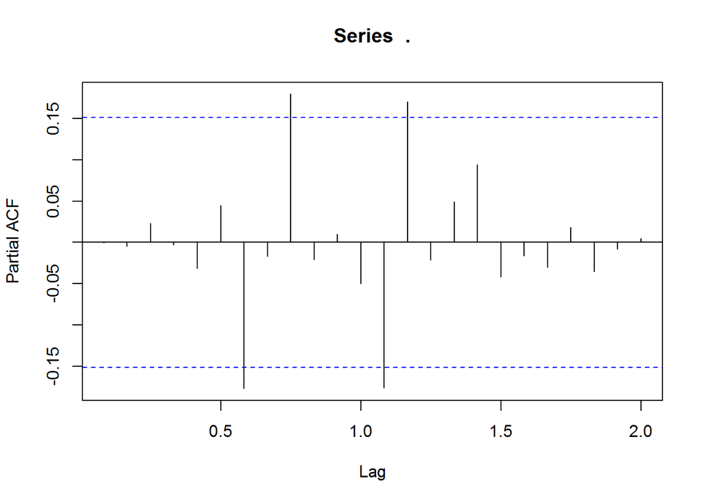

Abaixo identificamos o modelo pensado com a adição do polinômio auto regressivo

$$(1-\phi_7B^7-\phi_9B^9-\phi_{13}B^{13}-\phi_{14}B^{14})(\psi_1B-\psi_2B^2-\psi_3B^3-\psi_4B^4-\psi_5B^5)(1-B^{12})z_t=(1-\Theta_1B-\Theta_2B^2)a_t$$

```r
mod2 = arima(Dados_IPI_Treino , order = c(14,1,5), seasonal = c(0,1,2),
            fixed=c(0,0,0,0,0,0,NA,0,NA,0,0,0,NA,NA,NA,NA,NA,NA,NA,NA,NA))

summary(mod2)
```

[output not shown]

### Diagnostico AR

Vamos realizar testes de diagnósticos para avaliar o modelo sugerido pelo *auto.arima* com a adição do polinômio auto regressivo atravéz dos gráficos de autocorrelação e de autocorrelação parcial e também com o teste Ljung-Box

#### Autocorrelação

Podemos analisar a autocorrelação da série para o modelo com polinômio auto regressivo

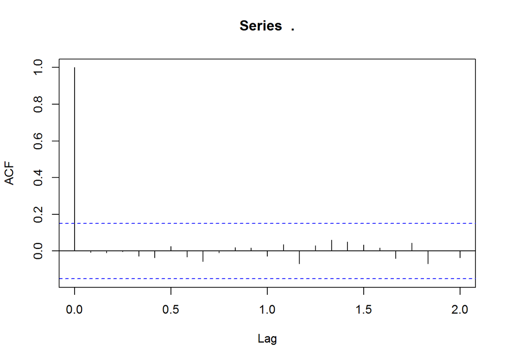

#### Autocorrelação Parcial

Podemos analisar a autocorrelação parcial da série para o modelo com polinômio auto regressivo

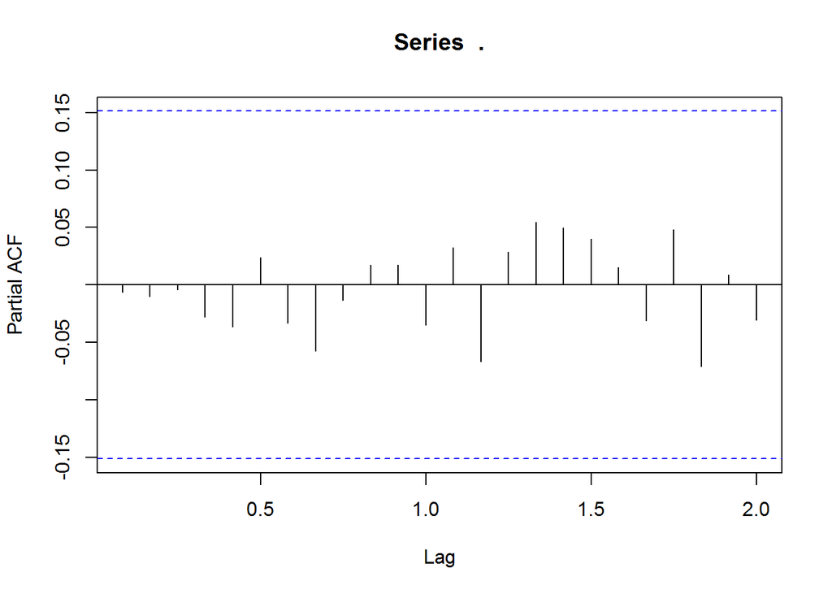

#### Teste Ljung-Box

```
##
##  Ljung-Box test
##
## data:  Residuals from ARIMA(14,1,5)(0,1,2)[12]
## Q* = 6.0828, df = 3, p-value = 0.1076
##
## Model df: 21.   Total lags used: 24
```

```
##
##  Ljung-Box test
##
## data:  Residuals from ARIMA(14,1,5)(0,1,2)[12]
## Q* = 15.703, df = 9, p-value = 0.07335
##
## Model df: 21.   Total lags used: 30
```

```
##
##  Ljung-Box test
##
## data:  Residuals from ARIMA(14,1,5)(0,1,2)[12]
## Q* = 19.994, df = 15, p-value = 0.1722
##
## Model df: 21.   Total lags used: 36
```

# Previsão

Vamos fazer a previsão dos dados da série IPI para o ano de 1999 de janeiro até dezembro

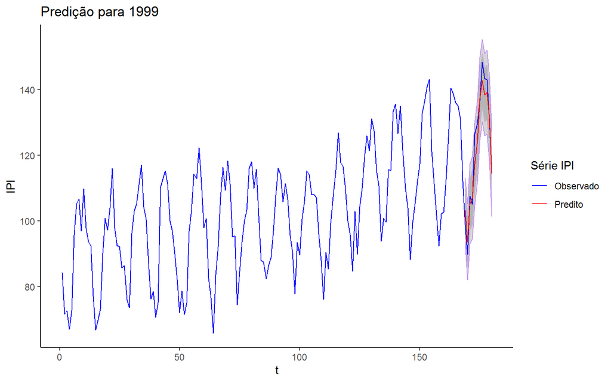

```r
dados_predicao <- tibble(predito = rep(NA, 168),
       lo_80 = rep(NA, 168),
       hi_80 = rep(NA, 168),
       lo_95 = rep(NA, 168),
       hi_95 = rep(NA, 168),
       observado = Dados_IPI[1:168],
       t = 1:168) %>%
  bind_rows(
    forecast(mod2, h = 12) %>%
    as_tibble() %>%
    mutate(observado = as.numeric(tail(Dados_IPI, 12))) %>%
    rename_all(., ~str_to_lower(.)) %>%
    rename_all(., ~str_replace(., pattern = ' ', replacement = '_')) %>%
    rename(predito = point_forecast) %>%
    mutate(t = 169:180)
  ) %>%
  pivot_longer(c(observado, predito))

dados_predicao %>%
  ggplot(aes(x = t, y = value, color = name)) +
  geom_ribbon(aes(ymin = lo_80, ymax = hi_80), color = '#e8d5f9', alpha = 0.2) +
  geom_ribbon(aes(ymin = lo_95, ymax = hi_95), color = '#c495f0', alpha = 0.2) +
  geom_line() +
  labs(x = 't', y = 'IPI', title = 'Predição para 1999') +
  scale_color_manual('Série IPI',labels = c("Observado", "Predito") ,values = c('blue', 'red'))
```

# Medidas de Acurácia

Podemos observar que o RMSE (raiz quadrada do erro quadrado médio) é similar entre os dados de treino e os dados de teste. Isto também acontece com o MAE (erro absoluto médio). Podemos dizer que o modelo tem uma boa capacidade para prever dados futuros que não foram utilizados no ajuste.

```
##                     ME     RMSE     MAE        MPE     MAPE      MASE
## Training set 0.1984655 4.794725 3.51393 0.01363975 3.576821 0.5973206
## Test set     1.6963343 4.363018 3.63431 1.03820321 2.977496 0.6177837
##                      ACF1 Theil's U
## Training set -0.006484464        NA
## Test set      0.129151683 0.3554074
```

## EQM

Com o último modelo apresentado obtemos um EQM de 19.03593